# hw4_1

b03801053公衛四劉倢如

2017年11月22日

承接hw3臉書主題，分析連續不同天文本的關係

```r
#import data
source("hw3txt.R")
#corpus to tdm
d.corpus <- Corpus(VectorSource(seg))
```

由於作業3文字雲主題，可以看出高雄市長發文裡面，“高雄”的字詞在各篇文章中，占有很高的比例，因此利用相關係數，尋找相關性0.7以上與高雄相關的字，利用位置1的“優質”與位置53的“商機”，來看看各篇文本相關的關係

```r
#沒有做過數學權重的tdm
##到這裡就整理出將鋸子拆開來的矩陣檔
tdm <- TermDocumentMatrix(d.corpus,
       control = list(wordLengths = c(1, Inf)))
#View(inspect(tdm[1:9, 1:11]))

ass = findAssocs(tdm, "高雄", 0.70)
ass
```

```
## $高雄
##       優質       取得         已         項     產\xab       廠商
##       0.89       0.83       0.79       0.79       0.77       0.77
##     食\xab       農漁   十分重視   大飽口福     工\xb7     及民眾
##       0.76       0.75       0.72       0.72       0.72       0.72
##         戶       戶及       戶到       方面   水產\xab         乎
##       0.72       0.72       0.72       0.72       0.72       0.72
##       市場       民眾       生產     用\xab       向來       安全
##       0.72       0.72       0.72       0.72       0.72       0.72
##       成長         局       把關       決心     迄今已         呷
##       0.72       0.72       0.72       0.72       0.72       0.72
##         定       物產         者       表示         型       政策
##       0.72       0.72       0.72       0.72       0.72       0.72
##       首度       倍並       原來       展今       展及       展以
##       0.72       0.72       0.72       0.72       0.72       0.72
##     展高雄       展售       展覽   展覽\xc0     海洋局       烘焙
##       0.72       0.72       0.72       0.72       0.72       0.72
##       特別       參與     參\xc6     商\xab       商機       國產
##       0.72       0.72       0.72       0.72       0.72       0.72
##   國際飯店       將近       清真       產銷       盛大       規模
##       0.72       0.72       0.72       0.72       0.72       0.72
##       責任         章         備       提高       無限       進入
##       0.72       0.72       0.72       0.72       0.72       0.72
##       進軍         間       項目         飲         僅       搭乘
##       0.72       0.72       0.72       0.72       0.72       0.72
##       誠摯       農及   農委\xb7 農畜產\xab     農\xb7     幕典禮
##       0.72       0.72       0.72       0.72       0.72       0.72
##       \xba   滿載而歸       精選       \xbb       輕軌       履歷
##       0.72       0.72       0.72       0.72       0.72       0.72
##     穆斯林       擴增       豐富         證       攤位       歡迎
##       0.72       0.72       0.72       0.72       0.72       0.72
##       驗證       輔導
##       0.72       0.71
```

```r
# tf-idf computation
N = tdm$ncol
tf <- apply(tdm, 2, sum)
idfCal <- function(word_doc)
{
  log2( N / nnzero(word_doc) )
}
idf <- apply(tdm, 1, idfCal)


doc.tfidf <- as.matrix(tdm)
for(x in 1:nrow(tdm))
{
  for(y in 1:ncol(tdm))
  {
    doc.tfidf[x,y] <- (doc.tfidf[x,y] / tf[y]) * idf[x]
  }
}


# 畫出 tf-idf 統計圖
library(plotly)
topID = lapply(rownames(as.data.frame(ass)), function(x)
  which(rownames(tdm) == x))
topID = unlist(topID)
plot_ly(data = as.data.frame(doc.tfidf),
        x = as.numeric(colnames(doc.tfidf)),
        y = doc.tfidf[topID[1],],
        name = rownames(doc.tfidf)[topID[1]],
        type = "scatter", mode= "box") %>%
add_trace(y = doc.tfidf[topID[53],],
          name = rownames(doc.tfidf)[topID[53]])
```

[interactive chart not shown]

於是發現，第10篇文章，是“優質”與“商機”最相關的文章；而第6篇與第10篇文本都是與優質相關的文章

再來是看文章之間 的相關性，利用cos similarity來看

```r
# get short doc matrix
nonzero = (doc.tfidf != rep(0,11))
nonzeroid = which(row_sums(nonzero) != 0)
q <- rownames(doc.tfidf[nonzeroid,])
all.term <- rownames(doc.tfidf)
loc <- which(all.term %in% q)
s.tdm <- doc.tfidf[loc,]
View(s.tdm)

# result : cos similarity ranking


cos.sim <- function(x, y)
{
  (as.vector(x) %*% as.vector(y)) / (norm(as.matrix(x)) * norm(y))
}

doc.cos <- apply(s.tdm[,1:11], 2, cos.sim,
                 y=as.matrix(s.tdm[,11]))
orderDoc <- doc.cos[order(doc.cos, decreasing = TRUE)]
plot_ly(data = as.data.frame(orderDoc),
        x = rownames(as.data.frame(orderDoc)),
        y = orderDoc,
        name = rownames(doc.tfidf)[topID[1]],
        type = "bar", mode= "box")
```

[interactive chart not shown]

藉由圖發現第11篇與第8篇文本的相關性可能是最高的，而回顧文本內容，也可以看出這兩篇主要內容是與國際接軌有關係的文章

藉由k-means來做分群

```r
str(doc.tfidf)
```

```
##  num [1:928, 1:11] 0 0.00154 0.03887 0.02106 0.03887 ...
##  - attr(*, "dimnames")=List of 2
##   ..$ Terms: chr [1:928] "c" "\xa4" "又" "大家" ...
##   ..$ Docs : chr [1:11] "1" "2" "3" "4" ...
```

```r
summary(doc.tfidf)
```

```
##        1                  2                  3
##  Min.   :0.000000   Min.   :0.000000   Min.   :0.000000
##  1st Qu.:0.000000   1st Qu.:0.000000   1st Qu.:0.000000
##  Median :0.000000   Median :0.000000   Median :0.000000
##  Mean   :0.002721   Mean   :0.002604   Mean   :0.002514
##  3rd Qu.:0.000000   3rd Qu.:0.000000   3rd Qu.:0.000000
##  Max.   :0.110536   Max.   :0.075865   Max.   :0.060692
##        4                 5                  6
##  Min.   :0.00000   Min.   :0.000000   Min.   :0.000000
##  1st Qu.:0.00000   1st Qu.:0.000000   1st Qu.:0.000000
##  Median :0.00000   Median :0.000000   Median :0.000000
##  Mean   :0.00219   Mean   :0.002772   Mean   :0.002396
##  3rd Qu.:0.00000   3rd Qu.:0.000000   3rd Qu.:0.000000
##  Max.   :0.20350   Max.   :0.108107   Max.   :0.091519
##        7                  8                  9
##  Min.   :0.000000   Min.   :0.000000   Min.   :0.000000
##  1st Qu.:0.000000   1st Qu.:0.000000   1st Qu.:0.000000
##  Median :0.000000   Median :0.000000   Median :0.000000
##  Mean   :0.002604   Mean   :0.002788   Mean   :0.002705
##  3rd Qu.:0.000000   3rd Qu.:0.000000   3rd Qu.:0.000000
##  Max.   :0.135664   Max.   :0.116774   Max.   :0.092498
##        10                 11
##  Min.   :0.000000   Min.   :0.000000
##  1st Qu.:0.000000   1st Qu.:0.000000
##  Median :0.000000   Median :0.000000
##  Mean   :0.002463   Mean   :0.002578
##  3rd Qu.:0.000000   3rd Qu.:0.000000
##  Max.   :0.070601   Max.   :0.104831
```

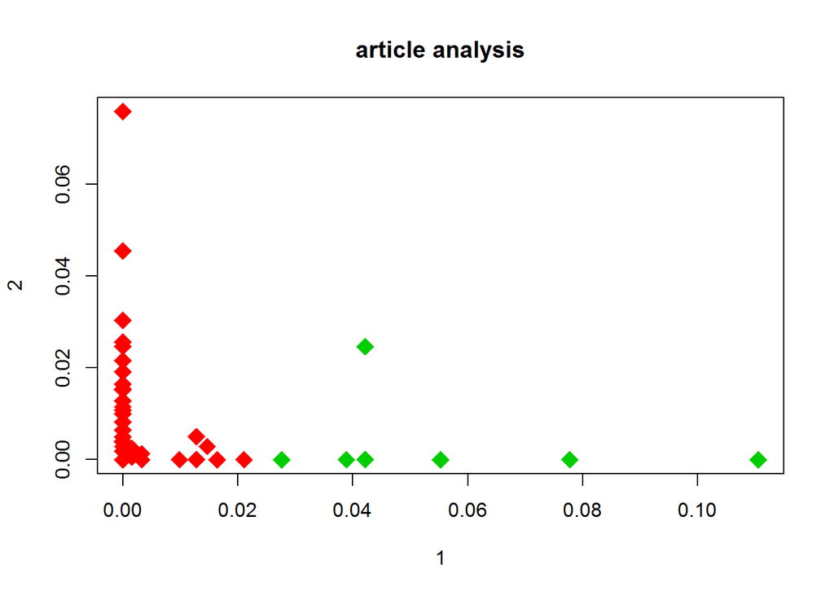

```r
set.seed(11)#因為有11篇文章
kmeansOut <- kmeans(doc.tfidf, 2, nstart = 50)
plot(doc.tfidf, col =(kmeansOut$cluster +1) , main="article analysis", pch=18, cex=2)
```

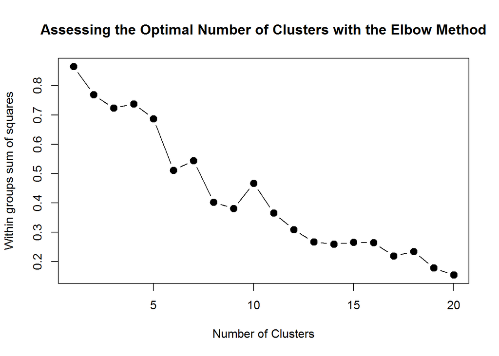

```r
mydata <- doc.tfidf
wss <- (nrow(mydata)-1)*sum(apply(mydata,2,var))
for (i in 1:20) wss[i] <- sum(kmeans(mydata,
                                     centers=i)$withinss)
plot(1:20, wss, type="b", xlab="Number of Clusters",
     ylab="Within groups sum of squares",
     main="Assessing the Optimal Number of Clusters with the Elbow Method",
     pch=20, cex=2)
```

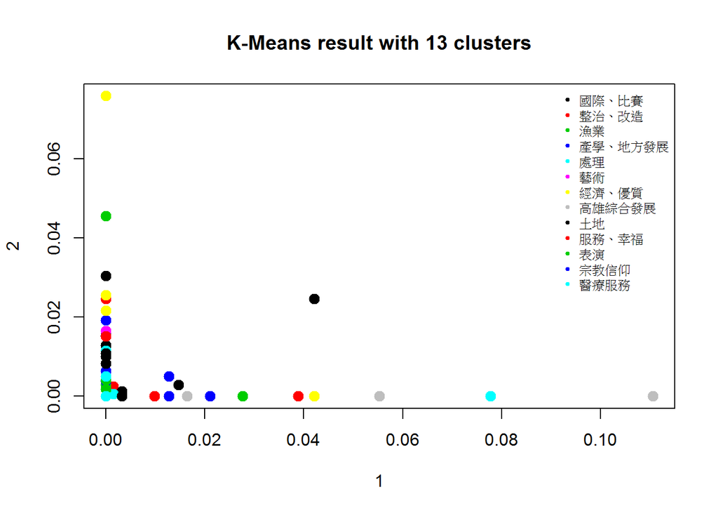

```r
set.seed(11)
km2 = kmeans(mydata, 13, nstart=50)

# Examine the result of the clustering algorithm


plot(mydata,  col =c(1:13), main="K-Means result with 13 clusters",pch =  20 ,cex=2)
legend('topright',c('國際、比賽','整治、改造','漁業','產學、地方發展','處理','藝術','經濟、優質','高雄綜合發展','土地','服務、幸福','表演','宗教信仰','醫療服務'),col = c(1:13),pch = 20,bty='n', cex=.75)
```

藉由k-means作分群 1.一開始先分成兩群畫圖看看，發現組間/組內的變異很小

2.藉由找到最佳分群的方法，分成13群，可以看出組間/組內的變異變大，因此分群現象清楚 但由於kmeans抓出來的字詞是從各篇文章抓出相近的一些字詞，發現出現的頻率相近，故根據分群的結果，做判斷後，給定比較大的分類項目名稱，分類過程中，明顯發現分群到第四與第六與第九群的字詞非常的少，發現整治、改造與產學、及地方發產有比較高的關係

再來利用PCA降維，來看看能分成幾群

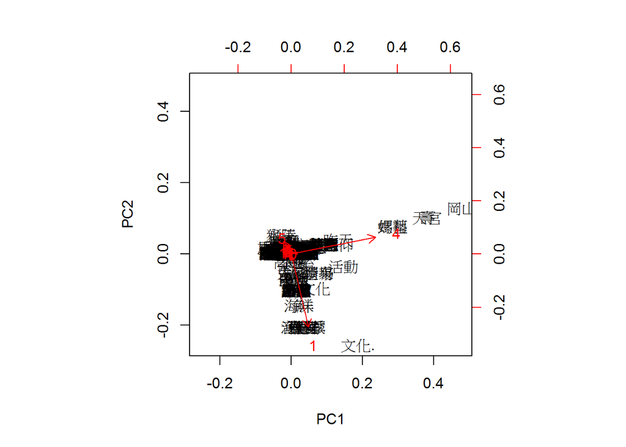

```r
#install.packages("devtools")
library(devtools)
#install_github("ggbiplot","vqv")
library(scales)
library(grid)
library(ggbiplot)
testTfidf = doc.tfidf
tfidf.pca <- prcomp(testTfidf)

#讓文字顯示成中文
biplot(tfidf.pca)
```

發現經過降維之後，抓下來的11篇文章中以，第一篇、第四篇、第五篇分群現象最明顯